# 4. Applied regression II

2023-02-13

> [*Back to content page*](https://flatter11.github.io/r.studio/)

Learning objectives

- Apply poisson and negative binomial regression models to count data
- Identify and apply suitable model to overdispersed data
- Identify influential observations
- Perform model diagnostics

# 1 Overdispersion

- In many situations, we find that count data have a particular property which makes the Poisson model unsuitable for use – the variance of our count data is appreciably larger than the mean, this is known as **‘overdispersion’**.
- We can generalise the Poisson regression model to include a **‘random effect’ ε<sub>i</sub>** in the rate λ
  - Introduce some uncertainty into the model –> larger variance
  - We can think of ε<sub>i</sub> as representing the effects of one or more unobserved explanatory variables

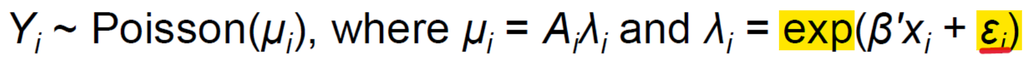

- In the special case where we allow **exp(ε<sub>i</sub>)** to follow a gamma distribution with **mean 1** and **variance α**, then **Yi** follows a **negative binomial distribution** [wiki](https://en.wikipedia.org/wiki/Negative_binomial_distribution) with
  - **Mean = μ<sub>i</sub>**
  - **Variance = μ<sub>i</sub> + αμ<sub>i</sub><sup>2</sup>**
    - Variance always greater than mean (coz αμ<sub>i</sub><sup>2</sup> is a non-negative part)
    - Larger α, larger variance
  - When we try to fit regression model for count data, we start with negative binomial model instead of poisson model and check whether alpha close to 0.

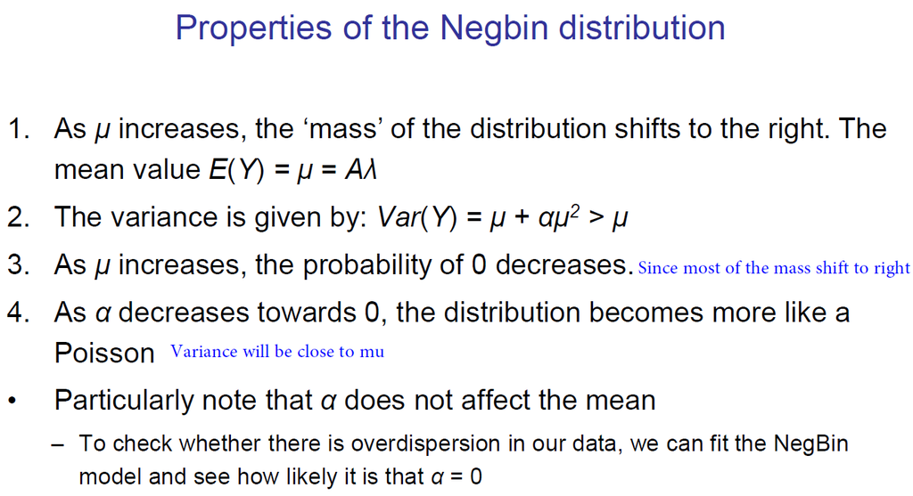

supplementary info

  ```r
  ## rpois(10000,5): generate 10000 number following poisson distribution with mean = 5
  mean(rpois(10000,5))
  var(rpois(10000,5))

  ## Generate negative binomial distribution with random effect following gamma mean=1, variance=2
  # mean = kϑ; variance = kϑ^2
  # shape k; rate β = 1/ϑ
  mean(rpois(10000, 5*rgamma(10000,1/2,1/2)))
  var(rpois(10000, 5*rgamma(10000,1/2,1/2))) #larger variance, suitable to describe count
  #data with overdispersion
  ```

##### Example – Epileptic seizures

- The file ‘exampleepilepsy.csv’ contains data from a RCT which compared progabide (therapy=1) with a placebo (therapy=0)
- For each patient we know:
  - the number of seizures (x) experienced in 8 weeks prior to randomisation
  - the number of seizures (y) experienced during the 8-week trial (let’s set A = 1 since all patients had the same follow-up)
  - We also know each patient’s age
- Was progabide more effective than placebo in reducing seizure frequency?

  ```r
  epilepsy <- read.csv("Folder/exampleepilepsy.csv")
  ```

## 1.1 Check overdispersion (not important)

Compare mean and variance to check overdispersion.

```r
mean(epilepsy$y)
var(epilepsy$y)
#We can see that y seems to be overdispersed, since the variance (823.475) is much larger
#than the mean (28.41)
```

```
## [1] 28.41379
## [1] 823.4749
```

Practice: Fit a poisson regression model for the number of seizures with an intercept only. Does your model fit the data satisfactorily?

```r
pois.epilepsy <- glm(y~1, data=epilepsy, family=poisson) #fit the model
deviance(pois.epilepsy)/df.residual(pois.epilepsy) #much greater than 1
```

## 1.2 Fitting NegBin model

- Unfortunately, the glm function in R only fits negative binomial regression model when α is known.
- For the case **when α is unknown** and has to be estimated from the parameter, use **glm.nb in the “MASS” (Modern Applied Statistics…) package**
  - `glm.nb(formula, data, subset, …)`
    - **formula**, **data** and **subset** same as glm
    - **family** not needed

```r
require(MASS)
## Fit a NegBin regression model
nb.epilepsy0 <- glm.nb(y~1, data=epilepsy)
summary(nb.epilepsy0)
```

```
##
## Call:
## glm.nb(formula = y ~ 1, data = epilepsy, init.theta = 1.38983642,
##     link = log)
##
## Deviance Residuals:
##     Min       1Q   Median       3Q      Max
## -2.9191  -0.9158  -0.6002   0.1676   2.5507
##
## Coefficients:
##             Estimate Std. Error z value Pr(>|z|)
## (Intercept)   3.3469     0.1141   29.34   <2e-16 ***
## ---
## Signif. codes:  0 '***' 0.001 '**' 0.01 '*' 0.05 '.' 0.1 ' ' 1
##
## (Dispersion parameter for Negative Binomial(1.3898) family taken to be 1)
##
##     Null deviance: 64.624  on 57  degrees of freedom
## Residual deviance: 64.624  on 57  degrees of freedom
## AIC: 507.19
##
## Number of Fisher Scoring iterations: 1
##
##
##               Theta:  1.390
##           Std. Err.:  0.253
##
##  2 x log-likelihood:  -503.188
```

- **Fitted mean (μ)** is exp(3.347) = 28.4 (vs observed mean = 28.4)
- In glm.nb, θ = 1 / α -> **Fitted variance (μ + αμ<sup>2</sup>)** is 28.4 + 28.42<sup>2</sup> /1.39 = 609.3 (vs observed variance = 823.5)

```r
## Fit a NegBin regression model to estimate therapy effect
nb.therapy1 <- glm.nb(y~therapy, data=epilepsy)
coef(nb.therapy1)
round(exp(cbind(coef(nb.therapy1), confint(nb.therapy1))),3) #need to take exponantial
deviance(nb.therapy1)/df.residual(nb.therapy1)
```

```
## (Intercept)     therapy
##   3.5378489  -0.4096274
##                     2.5 % 97.5 %
## (Intercept) 34.393 25.522 47.760
## therapy      0.664  0.428  1.028
## [1] 1.14985
```

- **Multiplicative effect**: The estimated effect of therapy (unadjusted) is to reduce the rate of seizures by 34% (RR = 0.66, 95% CI = 0.43 -1.03)
- The model fit the data satisfactorily.

```r
## Adjusting for the original covariates (x, age)
nb.therapy2 <- glm.nb(y~therapy+x+age, data=epilepsy)
round(exp(cbind(coef(nb.therapy2), confint(nb.therapy2))),3)
```

```
##                   2.5 % 97.5 %
## (Intercept) 6.485 2.865 14.747
## therapy     0.841 0.620  1.141
## x           1.031 1.023  1.039
## age         1.016 0.991  1.042
```

```r
## Adjust for log-transfomed x and age
#We assume baseline seizure (x) has less effect OR
#We think x doesn't have strong direct association with y so we log-transform it
epilepsy$log10x <- log10(epilepsy$x)
nb.therapy3 <- glm.nb(y~therapy+log10x+age, data=epilepsy)
round(exp(cbind(coef(nb.therapy3), confint(nb.therapy3))),3)
deviance(nb.therapy3)/df.residual(nb.therapy3)
```

```
##                   2.5 % 97.5 %
## (Intercept) 0.922 0.345  2.462
## therapy     0.737 0.553  0.981
## log10x      8.813 5.592 13.989
## age         1.014 0.990  1.038
## [1] 1.165512
```

- **Multiplicative effect**: The estimated effect of therapy (adjusted) is to reduce the rate of seizures by 26% (RR = 0.74, 95% CI = 0.55-0.98)
- The model fit the data satisfactorily.

## 1.3 Comparing models

- We can compare models based on the Akaike Information Criterion (AIC), which is defined as **AIC = 2k – 2ln(L)**
  - where k is the number of parameters in the model, L is the likelihood
    - To count number of parameter(k/df): each model includes an intercept term β<sub>0</sub>, scale parameter α and explanatory variables.
  - A **lower AIC** indicates a ‘better’ model
  - As a rule of thumb, a difference >= 2 is significant

  ```r
  AIC(nb.epilepsy0, nb.therapy1, nb.therapy2, nb.therapy3)
  ```

  ```
  ##              df      AIC
  ## nb.epilepsy0  2 507.1881
  ## nb.therapy1   3 505.8973
  ## nb.therapy2   5 462.8663
  ## nb.therapy3   5 455.6771
  ```

  ```r
  # From the above table we conclude that the AIC favors Model 3.
  ```

##### Conclusions from epilepsy example data

- We can present the adjusted relative risk of seizures for progabide compared to placebo, which is 0.74 (95% CI: 0.55-0.98)
  - We can say that the seizure rate varies a great deal between patients
- We have seen that the log-transformed baseline seizure rate is a more useful explanatory variable than the original seizure rate (model 3)
  - The fit of the NegBin model seems to be acceptable

Practice:

- Fit a poisson regression model for the number of seizures, to estimate the therapy effect adjusted for log10x and age.
- Does your model fit the data satisfactorily?
- How does it compare with the negative binomial model?

```r
pois.epilepsy1 <- glm(y ~ therapy+log10x+age, data=epilepsy, family="poisson")
deviance(pois.epilepsy1)/df.residual(pois.epilepsy1) #does not fit well
AIC(pois.epilepsy1, nb.therapy3)
```

# 2 Influential observations

1. Leverage
   - How much an observation differs from the mean of the predictor variables (i.e., unusual predictor values, left figure)
2. Cook’s distance
   - Change in predicted values if an observation were excluded (right figure)

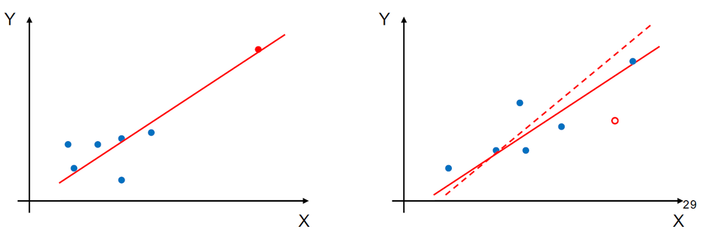

## 2.1 Leverage

- Leverage values are often used for **detecting observations that have a large impact** on the predicted values
  - `hatvalues(model)`
  - Bounded by 0 and 1
  - Average value of leverage values = k/n
    - k: number of estimated parameters in the model, including the constant/intercept
    - n: sample size
  - Rough guideline: observations with values **> 2k/n** are influential
    - In the MVC example (MVC = α + β1age + β2height), 2k/n = 2 × 3 / 41 = 0.1463

  ```r
  mvc <- read.csv("Folder/mvc.csv")
  mvc.r <- mvc
  mvc.r$height[41] <- 178 #create 1 single influential observation
  mvc.r.lm <- lm(MVC ~ height + age, data=mvc.r)
  sort(hatvalues(mvc.r.lm), decreasing=T) #Calculate leverage statistics
  ```

  ```
  ##         41         36          7         39          1         40         37
  ## 0.17947069 0.17414856 0.15004733 0.14218370 0.13776073 0.11421299 0.11226514
  ##         30         38         17         35          2         12          9
  ## 0.10987053 0.10818219 0.09832297 0.09734495 0.07903710 0.07723559 0.07436060
  ##          4          3         24         27         10         32         26
  ## 0.07308259 0.07150184 0.07052102 0.06815930 0.06144896 0.06024465 0.05911810
  ##         29         25         13          5          6         22         21
  ## 0.05860663 0.05590691 0.05573343 0.05550758 0.05550758 0.05315284 0.05268320
  ##          8         34         31         11         33         14         28
  ## 0.05066261 0.05036987 0.04925369 0.04614485 0.04560045 0.03832624 0.03800230
  ##         20         15         18         16         19         23
  ## 0.03259448 0.03038210 0.02948528 0.02846689 0.02817681 0.02691674
  ```

  ```r
  #Observations 41, 36, 7 are influential
  ```

## 2.2 Cook’s distance (D<sub>i</sub>)

- A measure of the overall influence of a case on a model as a whole. **How much deleting an observation will affect the model**
  - `cooks.distance(model)`
  - Tells us how much deleting a case affects not only the residual for that case, but also the residuals of the remaining cases (fyi)
  - Cook’s distance depends on the standardized residuals of a case and its leverage.(fyi)
    - $D_i = \frac{Z^2_i \times h_i}{(1-h_i)k}$
    - where Z<sub>i</sub> is the standardized residual, h<sub>i</sub> is the leverage, k is the number of parameters
  - Rough guideline: observations with D<sub>i</sub> **> 4/n** are influential
    - In the MVC example, 4/n = 4 / 41 = 0.0976

  ```r
  sort(round(cooks.distance(mvc.r.lm),2), decreasing=T) #Calculate Cook’s distance
  ```

  ```
  ##   41    5    8   37   21    1   13   33   40    7    9   14    2   17   26   32
  ## 0.35 0.10 0.09 0.08 0.06 0.05 0.05 0.05 0.05 0.04 0.04 0.04 0.03 0.03 0.03 0.02
  ##    6   18   19   22   27   29    3    4   10   11   12   15   16   20   23   24
  ## 0.01 0.01 0.01 0.01 0.01 0.01 0.00 0.00 0.00 0.00 0.00 0.00 0.00 0.00 0.00 0.00
  ##   25   28   30   31   34   35   36   38   39
  ## 0.00 0.00 0.00 0.00 0.00 0.00 0.00 0.00 0.00
  ```

  ```r
  #Observations 41, 5 are influential
  ```

## 2.3 Best measure

Identify influential observations automatically (Include cooks distance and leverage etc.)  
`influence.measures(model)`

```r
influence.measures(mvc.r.lm)
```

```
## Influence measures of
##   lm(formula = MVC ~ height + age, data = mvc.r) :
##
##       dfb.1_  dfb.hght  dfb.age    dffit cov.r   cook.d    hat inf
## 1   0.260311 -0.215759 -0.34413  0.40550 1.157 5.48e-02 0.1378
## 2  -0.000466 -0.036551  0.21085 -0.27825 1.094 2.59e-02 0.0790
## 3  -0.019309  0.003888  0.09313 -0.11770 1.150 4.72e-03 0.0715
## 4  -0.000607  0.004762 -0.02322  0.03161 1.168 3.42e-04 0.0731
## 5  -0.127377  0.055068  0.43291 -0.58385 0.741 1.01e-01 0.0555   *
## 6  -0.040779  0.017630  0.13859 -0.18691 1.093 1.18e-02 0.0555
## 7   0.289409 -0.268703 -0.20275  0.32960 1.213 3.66e-02 0.1500
## 8  -0.110668  0.044584  0.38772 -0.54467 0.750 8.83e-02 0.0507   *
## 9   0.169494 -0.208567  0.15429 -0.36684 1.025 4.41e-02 0.0744
## 10 -0.020073  0.027522 -0.03332  0.06468 1.148 1.43e-03 0.0614
## 11 -0.012105  0.019613 -0.03452  0.06633 1.127 1.50e-03 0.0461
```

[output cut: 30 more lines]

```r
#Observations 5, 8, 36, 39, 41 are influential
```

## What to do?

Don’t throw away data easily without justification

1. Check if there’s any typo (reassess if the data came from the target population)
2. Perform **sensitivity analysis**
   - Do the analysis again excluding influential observations
   - Do the results change qualitatively if we remove the outliers?

# 3 Model diagnostics

Why model diagnostics?

- Estimation method and statistical tests are based on model assumptions.General consequences of violated assumptions: a) Biased estimated coefficients or standard errors b) Inefficient estimation (achieving lower precision with the same sample size)
- Model diagnostics: **Identify any potential violated assumptions**. If yes, assess the extent of violation. Acknowledge limitation of the fitted model Or suggest an alternative statistical model if assumptions seriously violated

## 3.1 Assumptions of linear regression model

1. Linearity: Linear relationship between predictors(x) and dependent variable (y)
2. Constant variance of the errors (Homoscedasticity) (spread of “bell shaped curve” is constant)
3. Normality of the errors (“bell shaped curve”)
4. Independence: No correlation / autocorrelation between the errors
- The last three assumptions can be summarized as $ε iid ~ N(0, σ2)$ where iid = independently and identically distributed
- Use **Residual plot** to identify violation of assumptions
  - Raw residual: Difference between observed outcome and estimated value`model$res`
    - $e=y-\widehat{y}$
  - Studentized residuals: Standardized residuals by each data point `rstudent(model)`
    - $r_i=\frac{e_i}{\widehat\sigma\sqrt{1-h_i}}$
    - If model assumptions are correct, studentized residuals will follow a t-distribution with mean = 0 and variance = 1

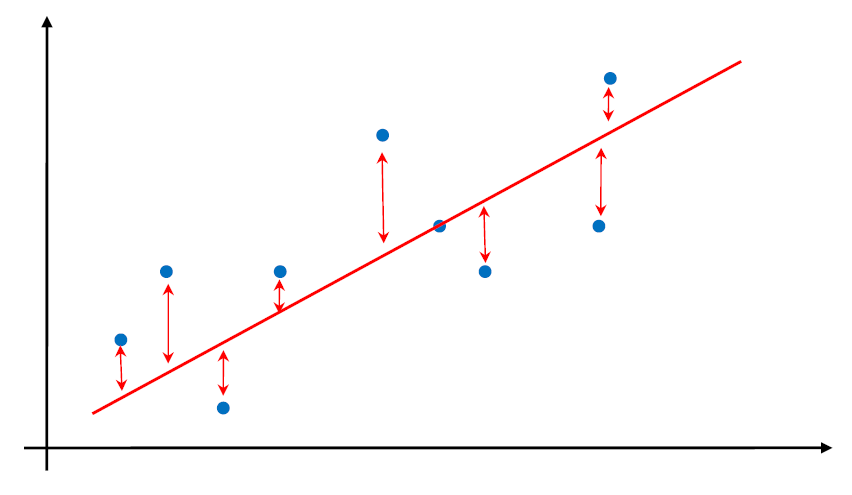

### A Nonlinearity

Plot **studentized residuals against each predictor (x)**

- Non-linear pattern suggests higher order terms or transformations of that predictor may be necessary
- Less useful for categorical variables (e.g., age grp 123)

`plot(x, residual)`

```r
mvc.lm <- lm(MVC ~ height + age, data=mvc) #fit a linear regression

## Create residuals and residual plot
rstudent(mvc.lm)
```

```
##           1           2           3           4           5           6
##  1.20384989 -0.96818436 -0.40623141  0.11452781 -2.43921515 -0.76069684
##           7           8           9          10          11          12
##  1.02006925 -2.39259342 -1.40718028  0.21178447  0.28122712 -0.34848769
##          13          14          15          16          17          18
##  1.73984068 -1.79550006 -0.03034708 -0.24227341  1.10758495  0.94991027
##          19          20          21          22          23          24
##  0.98162128  0.28247231  1.83180073  0.52496848 -0.19144388  0.05858779
##          25          26          27          28          29          30
##  0.26564588  1.06711856  0.49401378  0.12096068  0.41770248 -0.14449303
##          31          32          33          34          35          36
## -0.11547196  0.79066767  1.76910138  0.21607018 -0.02223248 -0.06511444
##          37          38          39          40          41
## -1.31406271 -0.05559492 -0.06444215 -1.12579372 -1.85601830
```

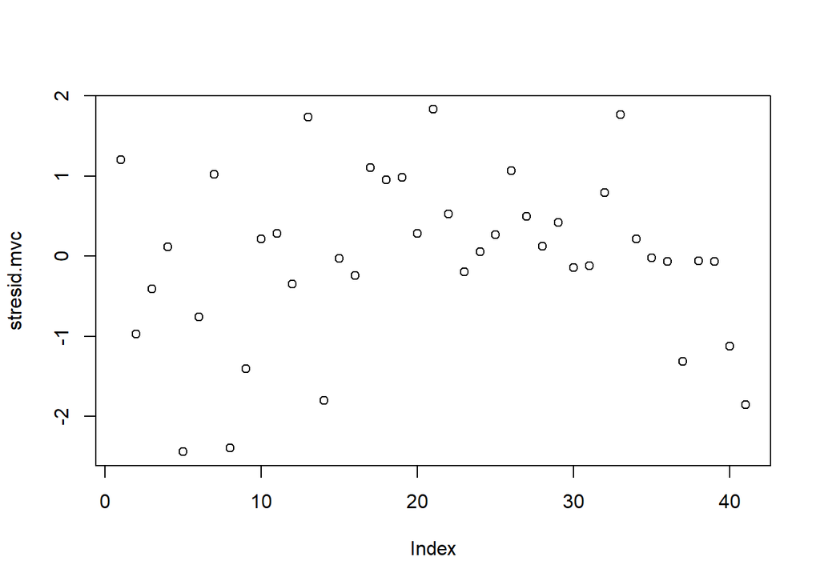

```r
stresid.mvc <- rstudent(mvc.lm)
plot(stresid.mvc) #residuals against observations
```

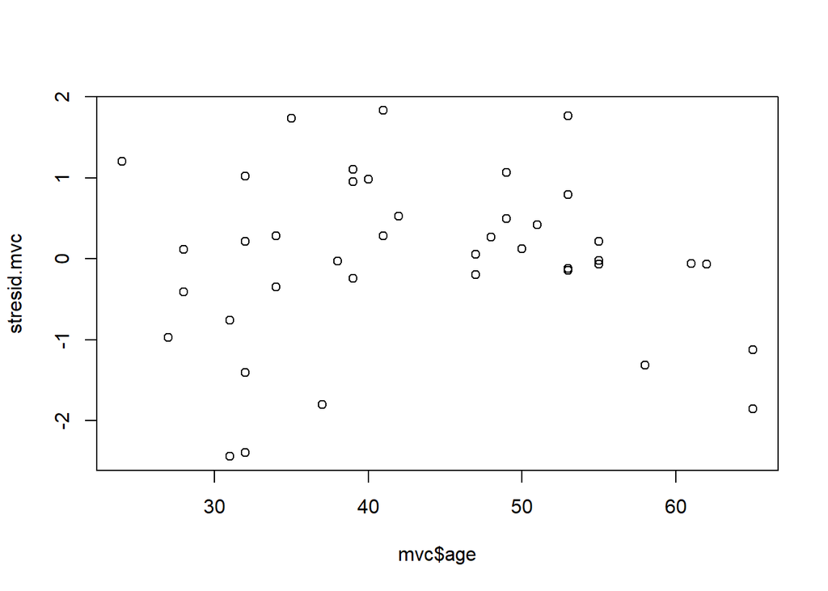

```r
## MVC Residual plots – against predictors (age, height)
plot(mvc$age, stresid.mvc) #no obvious pattern across age
```

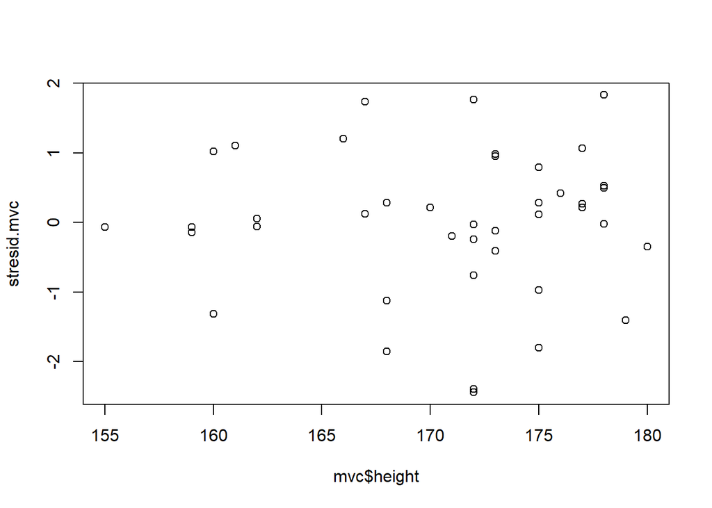

```r
plot(mvc$height, stresid.mvc) #no obvious pattern across height
```

Note we are just changing the ordering of residuals by plotting against age or height, but not changing the residuals themselves